# R 고급 통계분석 2일차 (2)

Sanghoo Yoon

사과품종 데이터를 보면 무게, 산도, 당도, 그리고 사과의 색이 있습니다.

이를 사용해서 다음 방법을 생각해 볼 수 있습니다.

```
사과의 품종을 자동으로 알 수 없을까?
```

# 분류분석

## 분류분석이란?

분류분석(classification analysis)란 학습을 통해 분류 기준을 모델화 하고 이를 통해 분류 예측하는 분류기법으로 이미지 판별, 스팸메일 판별, 신용도 측정 등 다양한 분양에서 활용되고 있습니다.

분류분석에는 의사결정나무, 나이브베이즈, 랜덤포레스트, 서포트 벡터머신, 로지스틱회귀모형 등이 있으며, 그 중 로지스틱회귀모형, 의사결정나무가 이해와 설명이 용이하여 많이 사용되고 있습니다. 이 외의 방법은 데이터의 이해보다 결과(분류)에 관심이 있는 경우 주로 활용됩니다.

## 훈련데이터

분류분석 모형을 세우기 위해서 가장 먼재 해야할 일을 훈련데이터와 테스터데이터를 구분하는 것입니다.

- 훈련데이터 : 모델 구축 시 활용할 데이터
- 테스트데이터 : 모델이 잘 분류 되었는지 확인할 데이터

보통 훈련 데이터와 테스트 데이터는 8:2, 7:3의 비율로 나눕니다. 또한 훈련 데이터는 데이터의 대표할만한 특성이 있는 데이터가 선정될 수 있도록 주의해야 합니다. 왜냐하면 훈련 데이터가 어떻게 선택되느냐에 따라 모델의 성능이 영향 받기 때문입니다. 주로 random sampling을 사용합니다.

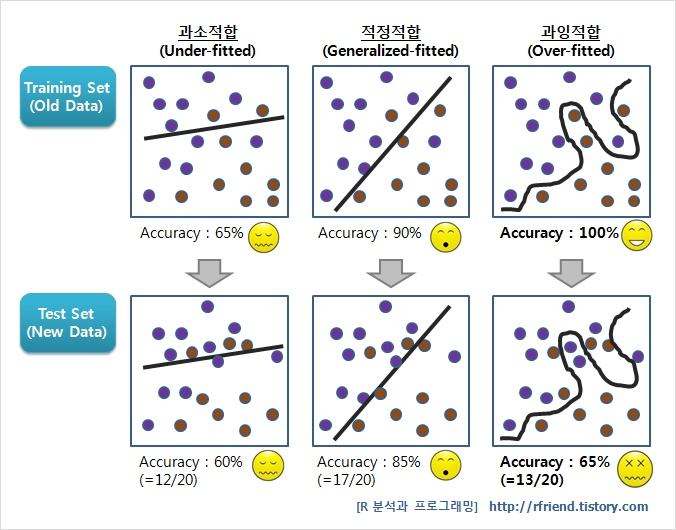

## 모델 평가하기

분류 모델의 적절성은 모델의 정확도(accuracy)를 통해 평가될 수 있습니다.

> 정확도 : 모델을 통해 제대로 분류된 개수/ 총 개수

하지만 정확도의 지표만으로 모델의 적절성을 평가하는데 문제점이 있습니다.

예를 들어 다음의 경우를 생각해보겠습니다.

```
실제자료 : 생산된 제품 총 1000개중 양품 990개, 불량품 10개

모델예측 : 모두 양품으로 예측

모델 정확도 : 990/1000=99%
```

놀랍게도 분류 모형을 세우지 않더라도 정확도가 99%가 됩니다. 하지만 불량을 판별하지 못하는 분류모델을 유용하다고 할 수 없습니다.

이를 보완하기 위해 혼돈행렬(confusion matrix)를 이용한 다양한 지표가 제시되었습니다.

|  |  | 실제값 |  |
| --- | --- | --- | --- |
|  |  | Y | N |
| 예측값 | Y | True Positive(TP) | False Positive(FP) |
|  | N | False Nagative(FN) | True Nagative (TN) |

- Precision = TP / (TP + FP) : Y로 예측된 것중에 Y의 비율
- Accuracy = TP+TN / (TP+FP+FN+TN) : 전체 예측 중 옳은 예측의 비율
- Recall = TP / (TP+FN) : 실제로 Y 인 것들 중 예측이 Y인 비율
- Specificity = TN / (FP + TN) : 실제로 N인 것들 중 예측이 N인 비율
- FP rate = FP / (FP + TN) : Y가 아닌데 Y로 예측된 비율
- F measure = 2 * Precision*Recall/(Precision+Recall) : Precision과 Recall의 조화 평균
- Kappa = Accuracy-(TP/(TP+FN)*TP/(TP+FP)+ TN/(TN+FP)*TN/(TN+FN)) /1- (TP/(TP+FN)*TP/(TP+FP)+ TN/(TN+FP)*TN/(TN+FN)) : 우연히 일치된 가능성

## 로지스틱 회귀모형

로지스틱 회귀모형은 반응변수 Y가 0 또는 1로 구분되는 이분형 자료에 적용되는 모형 다음과 같은 선형모형을 가정한다.

$$log ({{p} \over {1-p}})= \beta_0 + \beta_1X_1 + \cdots + \beta_p X_p + \epsilon$$
이런 변화를 로짓(logit) 변환이라 한다.

이분형 자료에 대해 회귀모형을 세우면 예측값이 범위를 벗어나는 문제가 발생한다.

```r
data(iris)

d<- iris[iris$Species == "virginica" | iris$Species =="versicolor",]  # 종이 Virginica와 versicolor 선택
d$Species <- factor(d$Species)
str(d)  # 이범주형 자료로 변환
```

```
## 'data.frame':    100 obs. of  5 variables:
##  $ Sepal.Length: num  7 6.4 6.9 5.5 6.5 5.7 6.3 4.9 6.6 5.2 ...
##  $ Sepal.Width : num  3.2 3.2 3.1 2.3 2.8 2.8 3.3 2.4 2.9 2.7 ...
##  $ Petal.Length: num  4.7 4.5 4.9 4 4.6 4.5 4.7 3.3 4.6 3.9 ...
##  $ Petal.Width : num  1.4 1.5 1.5 1.3 1.5 1.3 1.6 1 1.3 1.4 ...
##  $ Species     : Factor w/ 2 levels "versicolor","virginica": 1 1 1 1 1 1 1 1 1 1 ...
```

```r
# 만약 회귀모형으로 세운다면
# d$Species가 factor이므로

d$Species2 = as.numeric(d$Species)-1 #0과 1로 구성된 자료 생성
lm.out <- lm(Species2~Sepal.Length+Sepal.Width+Petal.Length+Petal.Width, data=d)
summary(lm.out)
```

```
##
## Call:
## lm(formula = Species2 ~ Sepal.Length + Sepal.Width + Petal.Length +
##     Petal.Width, data = d)
##
## Residuals:
##      Min       1Q   Median       3Q      Max
## -0.62692 -0.15178  0.01562  0.14191  0.53094
##
## Coefficients:
##              Estimate Std. Error t value Pr(>|t|)
## (Intercept)  -0.41864    0.26681  -1.569  0.11996
## Sepal.Length -0.19606    0.07223  -2.714  0.00789 **
## Sepal.Width  -0.30755    0.09452  -3.254  0.00158 **
## Petal.Length  0.38426    0.07818   4.915 3.70e-06 ***
## Petal.Width   0.68284    0.11212   6.090 2.38e-08 ***
## ---
## Signif. codes:  0 '***' 0.001 '**' 0.01 '*' 0.05 '.' 0.1 ' ' 1
##
## Residual standard error: 0.2385 on 95 degrees of freedom
## Multiple R-squared:  0.7839, Adjusted R-squared:  0.7748
## F-statistic: 86.15 on 4 and 95 DF,  p-value: < 2.2e-16
```

```r
summary(lm.out$fitted.values) # 예측값을 살펴보면 -0.3, 1.49와 같이 0과 1의 범위를 넘어가는 예측값 존재
```

```
##    Min. 1st Qu.  Median    Mean 3rd Qu.    Max.
## -0.3080  0.1291  0.5350  0.5000  0.8740  1.4940
```

하지만 로지스틱 회귀모형의 예측값은 0과 1 범위 내에서만 존재한다.

```r
out <- glm(Species2~Sepal.Length+Sepal.Width+Petal.Length+Petal.Width, data=d, family=binomial(link="logit"))
summary(out)
```

```
##
## Call:
## glm(formula = Species2 ~ Sepal.Length + Sepal.Width + Petal.Length +
##     Petal.Width, family = binomial(link = "logit"), data = d)
##
## Deviance Residuals:
##      Min        1Q    Median        3Q       Max
## -2.01105  -0.00541  -0.00001   0.00677   1.78065
##
## Coefficients:
##              Estimate Std. Error z value Pr(>|z|)
## (Intercept)   -42.638     25.707  -1.659   0.0972 .
## Sepal.Length   -2.465      2.394  -1.030   0.3032
## Sepal.Width    -6.681      4.480  -1.491   0.1359
## Petal.Length    9.429      4.737   1.991   0.0465 *
## Petal.Width    18.286      9.743   1.877   0.0605 .
## ---
## Signif. codes:  0 '***' 0.001 '**' 0.01 '*' 0.05 '.' 0.1 ' ' 1
##
## (Dispersion parameter for binomial family taken to be 1)
##
##     Null deviance: 138.629  on 99  degrees of freedom
## Residual deviance:  11.899  on 95  degrees of freedom
## AIC: 21.899
##
## Number of Fisher Scoring iterations: 10
```

```r
out$fitted.values # 예측 확률
```

```
##           51           52           53           54           55           56
## 1.171672e-05 4.856237e-05 1.198626e-03 4.220049e-05 1.408470e-03 1.018578e-04
##           57           58           59           60           61           62
## 1.305727e-03 5.351876e-10 1.458241e-05 1.481064e-05 3.990780e-08 3.744346e-05
##           63           64           65           66           67           68
## 9.947107e-08 7.988665e-04 1.378280e-08 2.828836e-06 1.326003e-03 1.481153e-08
##           69           70           71           72           73           74
## 5.959820e-02 8.712675e-08 4.048381e-01 3.405812e-07 2.248338e-01 4.023809e-05
##           75           76           77           78           79           80
## 1.410660e-06 7.060188e-06 7.124099e-04 2.760617e-01 9.651525e-04 1.290424e-10
##           81           82           83           84           85           86
## 8.469327e-08 5.298820e-09 8.707382e-08 8.676299e-01 2.169221e-03 2.129823e-04
##           87           88           89           90           91           92
## 2.979719e-04 2.551360e-04 7.884147e-07 1.109268e-05 3.969831e-05 1.596216e-04
##           93           94           95           96           97           98
## 4.360614e-07 8.158121e-10 1.502115e-05 2.541253e-07 3.085679e-06 2.309662e-06
##           99          100          101          102          103          104
## 6.163826e-11 2.344150e-06 1.000000e+00 9.996139e-01 9.999990e-01 9.997188e-01
##          105          106          107          108          109          110
## 9.999999e-01 1.000000e+00 8.908123e-01 9.999955e-01 9.999921e-01 1.000000e+00
##          111          112          113          114          115          116
## 9.902584e-01 9.997429e-01 9.999800e-01 9.999673e-01 9.999999e-01 9.999952e-01
##          117          118          119          120          121          122
## 9.976994e-01 9.999999e-01 1.000000e+00 9.204923e-01 9.999996e-01 9.995130e-01
##          123          124          125          126          127          128
## 1.000000e+00 9.484339e-01 9.999824e-01 9.995586e-01 8.245440e-01 8.022990e-01
##          129          130          131          132          133          134
## 9.999992e-01 9.712013e-01 9.999969e-01 9.999189e-01 9.999999e-01 2.048741e-01
##          135          136          137          138          139          140
## 9.664047e-01 1.000000e+00 9.999999e-01 9.964973e-01 6.691425e-01 9.998717e-01
##          141          142          143          144          145          146
## 1.000000e+00 9.999440e-01 9.996139e-01 1.000000e+00 1.000000e+00 9.999932e-01
##          147          148          149          150
## 9.991067e-01 9.989939e-01 9.999956e-01 9.776789e-01
```

```r
pred<-(ifelse(out$fitted.values>0.5,1,0)) #예측값이 0.5이상이면 1로 예측하고 0.5 미만이면 0으로 예측
```

예측결과를 분류표로 확인할 수 있다.